# network_analysis_R

#### 네트워크 분석의 기초

- 일반적인 텍스트에 적용할 수 있는 가장 기본적인 네트워크 분석을 연습해 본다.
  - 동시 출현 어휘 네트워크(Co-occurrence network): 동시 출현 개체/단어 관계를 네트워크로 구현해 본다.
  - 텍스트에서 원하는 개체/단어가 들어있는 문장/문서를 가져온다.
  - document-term matrix로 변환한다.
  - two-mode network를 one-mode network로 변환한다.

```r
# 필요한 라이브러리와 함수 집합 탑재
library(igraph)
source("utils.R")
```

##### 네트워크 그래프 만들어보기

```r
# A, B, C, D, E, F 등 6개의 구성 요소로 된 간단한 그래프를 만들어 본다.
g <- make_graph(~A-B-C-A, D-E-F-D, A-D)
```

```r
# 노드와 엣지 리스트를 출력
V(g)
E(g)
```

```
+ 6/6 vertices, named, from 7ab8175:
[1] A B C D E F



+ 7/7 edges from 7ab8175 (vertex names):
[1] A--B A--C A--D B--C D--E D--F E--F
```

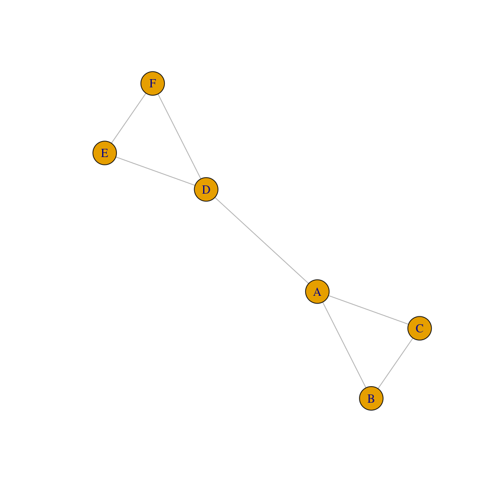

png

```r
# 그래프를 출력
plot(g)
```

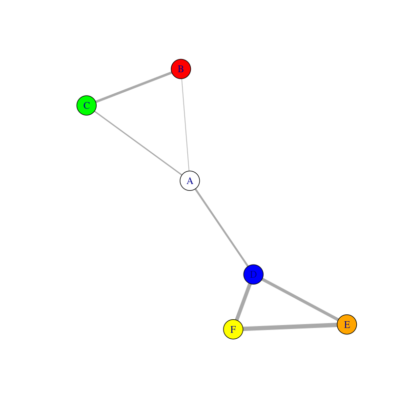

png

```r
V(g)$color <- c("white", "red", "green", "blue", "orange", "yellow")    # 각 노드에 색을 지정
E(g)$weight <- 1:7  # 각 엣지에 가중치를 지정. weight는 연결되는 노드들간의 연결 강도를 의미
plot(g, edge.width = E(g)$weight)
```

```r
# 그래프 객체를 adjacency matrix로 변환할 수 있음
adj_m <- as_adjacency_matrix(g, sparse = FALSE)
print(adj_m)
```

```
  A B C D E F
A 0 1 1 1 0 0
B 1 0 1 0 0 0
C 1 1 0 0 0 0
D 1 0 0 0 1 1
E 0 0 0 1 0 1
F 0 0 0 1 1 0
```

```r
# 그래프 객체를 edge list로 변환할 수 있음
edj_l <- as_edgelist(g)
print(edj_l)
```

```
     [,1] [,2]
[1,] "A"  "B"
[2,] "A"  "C"
[3,] "A"  "D"
[4,] "B"  "C"
[5,] "D"  "E"
[6,] "D"  "F"
[7,] "E"  "F"
```

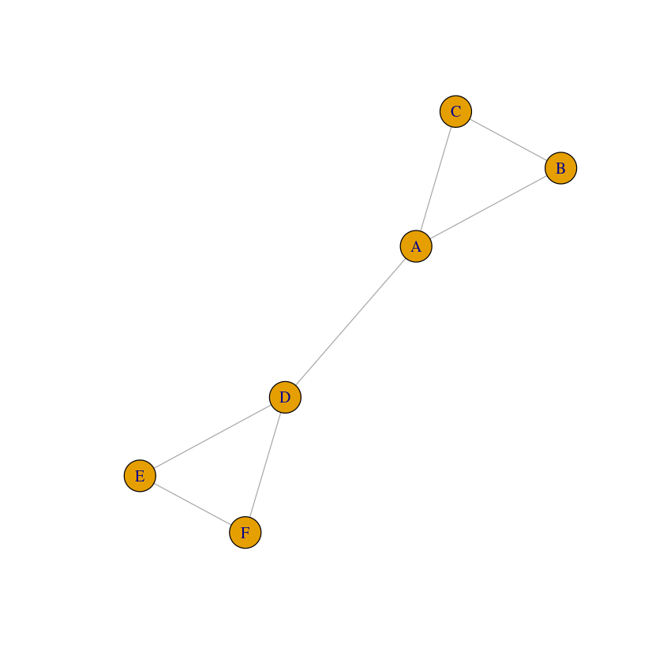

png

```r
# 매트릭스로 변환된 그래프 객체(adj_m)를 그래프로 다시 생성
g1 <- graph_from_adjacency_matrix(adj_m, mode = "undirected")
plot(g1)
```

```r
# affiliation matrix (individual-by-group matrix) -> two-mode network
A <- c(1, 1, 0, 0)
B <- c(1, 0, 1, 0)
C <- c(1, 0, 1, 0)
D <- c(0, 1, 0, 1)
E <- c(0, 0, 1, 1)

aff <- matrix(c(A, B, C, D, E), nrow = 5, byrow = TRUE)
dimnames(aff) <- list(c("A","B","C","D","E"), c("Group1","Group2","Group3","Group4"))
print(aff)
```

```
  Group1 Group2 Group3 Group4
A      1      1      0      0
B      1      0      1      0
C      1      0      1      0
D      0      1      0      1
E      0      0      1      1
```

```r
# 위 매트릭스를 두 가지의 네트워크로 표현할 수 있음
# (1) A, ... E의 그룹에 소속된 빈도 패턴을 이용하여 A-E의 네트워크로 표현
alpha_net <- aff %*% t(aff) # %*%는 매트릭스 multiplication 오퍼레이터. t 함수는 매트릭스의 행과 열을 치환(transpose)함
print(alpha_net)
```

```
  A B C D E
A 2 1 1 1 0
B 1 2 2 0 1
C 1 2 2 0 1
D 1 0 0 2 1
E 0 1 1 1 2
```

```r
# %*%의 작동 원리
# 매트릭스 곱하기를 위해서는 매트릭스1이 'm x n', 매트릭스2가 'n x p'이 되어야 함.
m1 <- matrix(c(1, 3, 4, 5, 8, 9), ncol = 3)
m2 <- matrix(c(2, 4, 5, 8, 9, 2), nrow = 3)
print(m1)
print(m2)
```

```
     [,1] [,2] [,3]
[1,]    1    4    8
[2,]    3    5    9
     [,1] [,2]
[1,]    2    8
[2,]    4    9
[3,]    5    2
```

```r
# %*%는 행렬 곱셈
print(m1 %*% m2)
```

```
     [,1] [,2]
[1,]   58   60
[2,]   71   87
```

```r
# *는 행렬의 각 요소별 곱셈
print(m1 * m2)  # 에러가 나는 이유는 동일한 형태의 매트릭스가 아니기 때문
```

```
Error in m1 * m2: non-conformable arrays
Traceback:


1. print(m1 * m2)
```

```r
print(m1 * t(m2))   # m2의 형태를 치환하면 에러가 나지 않고 계산됨
```

```
     [,1] [,2] [,3]
[1,]    2   16   40
[2,]   24   45   18
```

```r
print(m1 + t(m2))
```

```
     [,1] [,2] [,3]
[1,]    3    8   13
[2,]   11   14   11
```

```r
# 노드 A-E의 adjacency matrix를 그래프로 표현
alpha_g <- graph_from_adjacency_matrix(alpha_net, mode = "undirected", weighted = TRUE)
alpha_g
```

```
IGRAPH c21ef3d UNW- 5 12 --
+ attr: name (v/c), weight (e/n)
+ edges from c21ef3d (vertex names):
 [1] A--A A--B A--C A--D B--B B--C B--E C--C C--E D--D D--E E--E
```

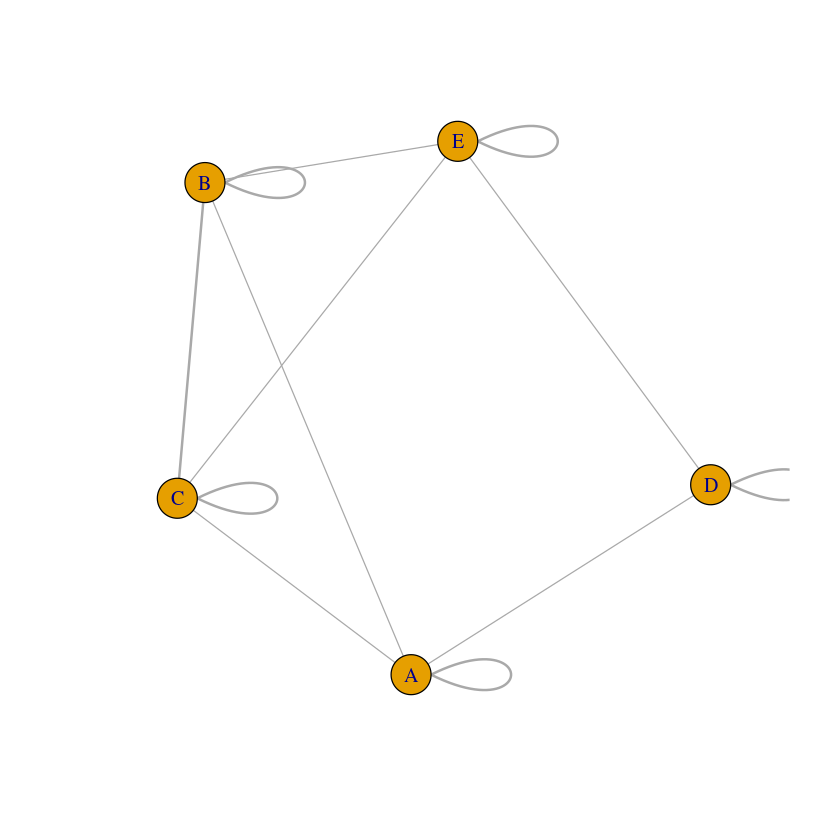

png

```r
plot(alpha_g, edge.width = E(alpha_g)$weight)
```

```r
# A-E의 adjacency matrix를 그래프로 표현할 때 diag를 FALSE로 설정 -> A-A 관계의 가중치를 0으로 만듦 (diag(alpha_net) <- 0 과 같은 효과)
alpha_g <- graph_from_adjacency_matrix(alpha_net, mode = "undirected", weighted = TRUE, diag = FALSE)
alpha_g
```

```
IGRAPH 1053b2a UNW- 5 7 --
+ attr: name (v/c), weight (e/n)
+ edges from 1053b2a (vertex names):
[1] A--B A--C A--D B--C B--E C--E D--E
```

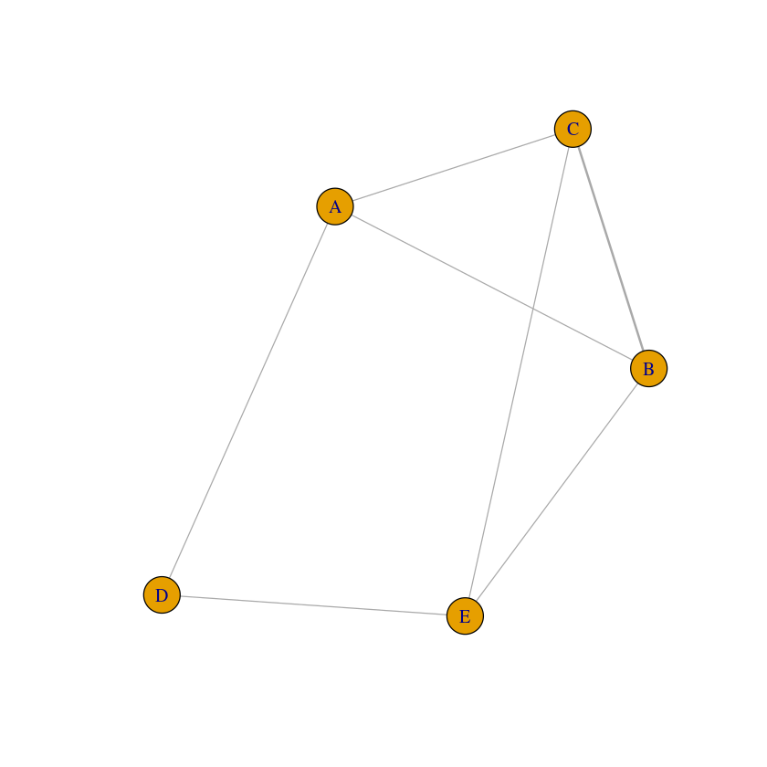

png

```r
plot(alpha_g, edge.width = E(alpha_g)$weight)
```

```r
# (2) 노드 A, ... E가 각 그룹에 소속된 빈도 정보를 이용하여 Group간의 네트워크로 표현
group_net <- t(aff) %*% aff
print(group_net)
```

```
       Group1 Group2 Group3 Group4
Group1      3      1      2      0
Group2      1      2      0      1
Group3      2      0      3      1
Group4      0      1      1      2
```

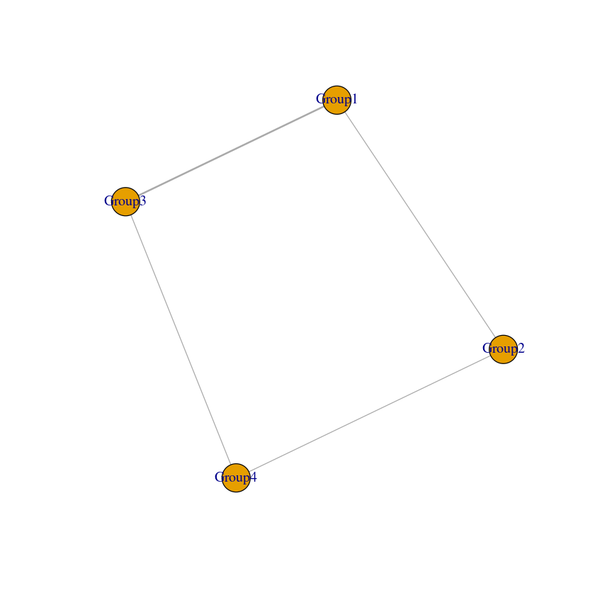

png

```r
group_g <- graph_from_adjacency_matrix(group_net, mode = "undirected", weight = TRUE, diag = FALSE)
plot(group_g, edge.width = E(group_g)$weight)
```

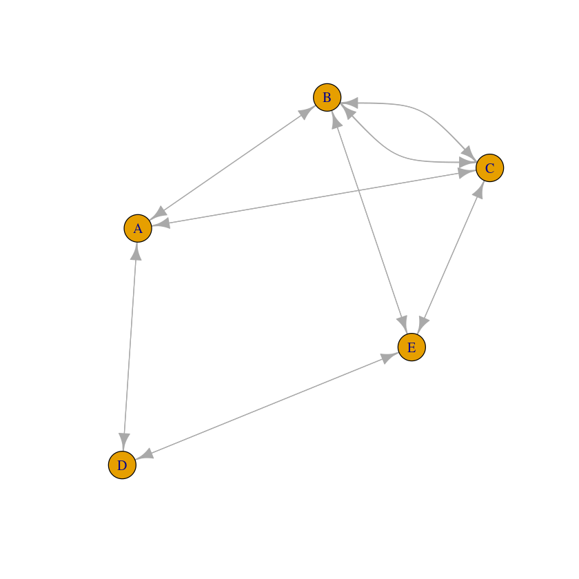

png

```r
# directed network로 표현
alpha_g1 <- graph_from_adjacency_matrix(alpha_net, mode = "directed", diag = FALSE)
plot(alpha_g1)
```

##### 데이터를 읽어 네트워크 그래프로 만들어보기

- edge list
- adjacency matrix

```r
# Edge list 읽어오기
royal_family <- read.csv("./analysis/network/uk_royal_family.csv")
print(head(royal_family))
```

```
         term1   term2 weight
1 Elizabeth II Charles      1
2 Elizabeth II  Philip      1
3       Philip Charles      1
4      Charles William      1
5        Diana William      1
6        Diana Charles      1
```

```r
royal_g <- graph_from_data_frame(royal_family, directed = FALSE)
royal_g
```

```
IGRAPH 0099014 UNW- 12 17 --
+ attr: name (v/c), weight (e/n)
+ edges from 0099014 (vertex names):
 [1] Elizabeth II--Charles            Elizabeth II--Philip
 [3] Philip      --Charles            Charles     --William
 [5] Diana       --William            Charles     --Diana
 [7] Diana       --Harry              Charles     --Harry
 [9] Charles     --Camilla            William     --Middleton
[11] Harry       --Meghan             Middleton   --Prince_George
[13] Middleton   --Princess_Charlotte Middleton   --Prince_Louis
[15] William     --Prince_George      William     --Princess_Charlotte
+ ... omitted several edges
```

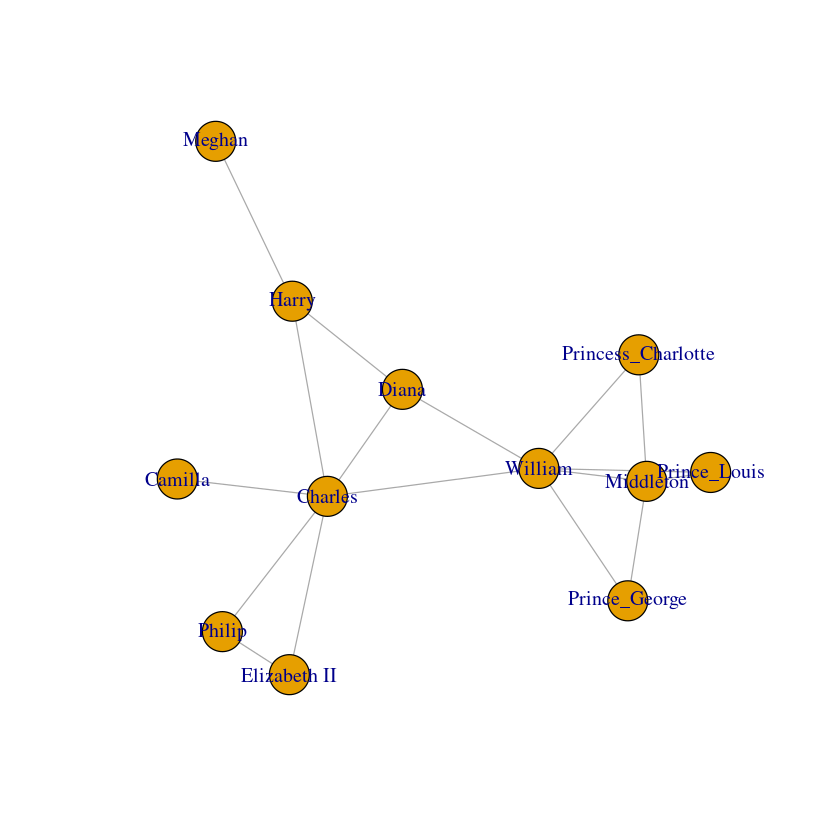

png

```r
plot(royal_g)
```

```r
V(royal_g)
```

```
+ 12/12 vertices, named, from 0099014:
 [1] Elizabeth II       Philip             Charles            Diana
 [5] William            Harry              Middleton          Camilla
 [9] Meghan             Prince_George      Princess_Charlotte Prince_Louis
```

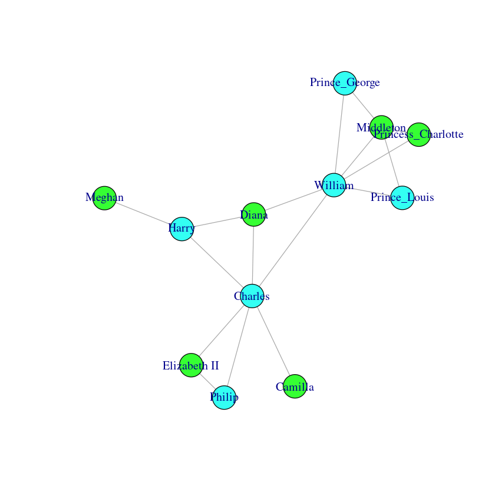

png

```r
# 노드의 성별에 따라 색을 구분
# 색상표 코드 참고 (https://htmlcolorcodes.com/)
V(royal_g)[c("Philip", "Charles", "William", "Harry", "Prince_George", "Prince_Louis")]$color <- "#33FFF3"
V(royal_g)[c("Elizabeth II", "Diana", "Middleton", "Camilla", "Meghan", "Princess_Charlotte")]$color <- "#36FF33"

plot(royal_g)
```

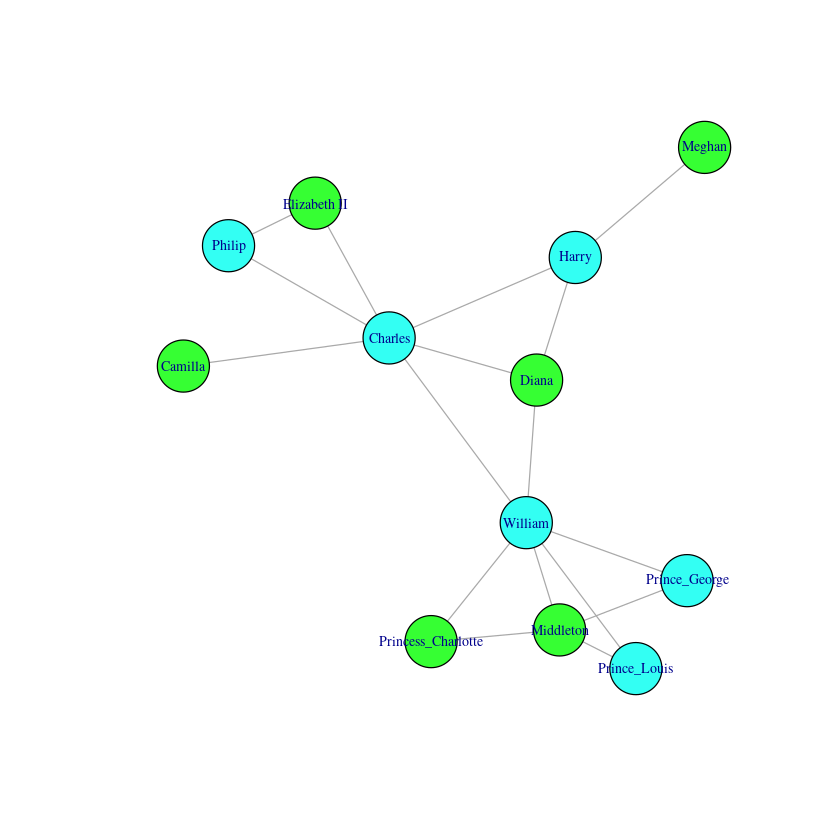

png

```r
V(royal_g)$label.cex <- 0.7
plot(royal_g, vertex.size = 20)
```

```r
# adjacency matrix 파일 읽어오기
adja_m <- as.matrix(read.csv("./analysis/network/sample_adjmatrix.csv", row.names = 1))
print(adja_m)
```

```
        Adam Betty Charles Daniel Esther Frank Gina
Adam       0     1       0      1      0     4    0
Betty      1     0       3      1      0     2    0
Charles    0     3       0      0      0     0    0
Daniel     1     1       0      0      1     1    0
Esther     0     0       0      1      0     1    0
Frank      4     2       0      1      1     0    2
Gina       0     0       0      0      0     2    0
```

```r
adja_g <- graph_from_adjacency_matrix(adja_m, mode = "undirected", weighted = TRUE)
adja_g
```

```
IGRAPH 0a8be18 UNW- 7 10 --
+ attr: name (v/c), weight (e/n)
+ edges from 0a8be18 (vertex names):
 [1] Adam  --Betty   Adam  --Daniel  Adam  --Frank   Betty --Charles
 [5] Betty --Daniel  Betty --Frank   Daniel--Esther  Daniel--Frank
 [9] Esther--Frank   Frank --Gina
```

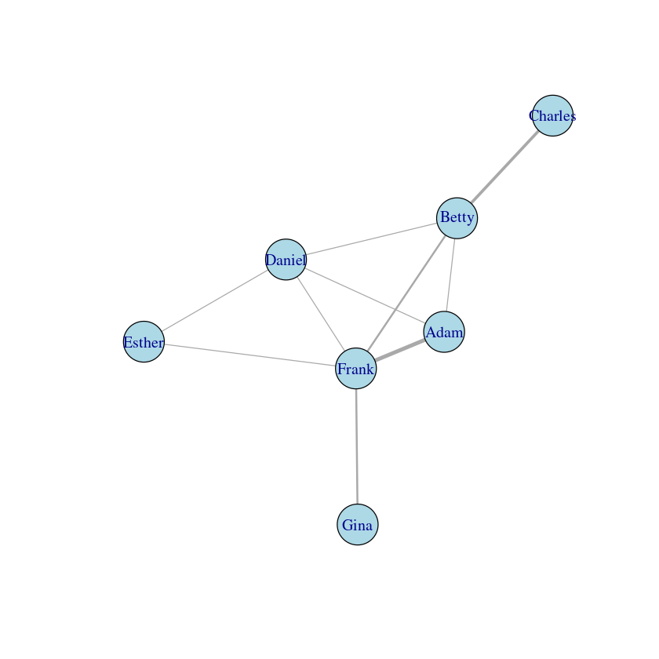

png

```r
V(adja_g)$color <- "lightblue"
plot(adja_g, edge.width = E(adja_g)$weight, vertex.size = 20)
```

##### 네트워크의 형태(shape)

- 레이아웃 함수로 레이아웃을 먼저 지정 후 plot

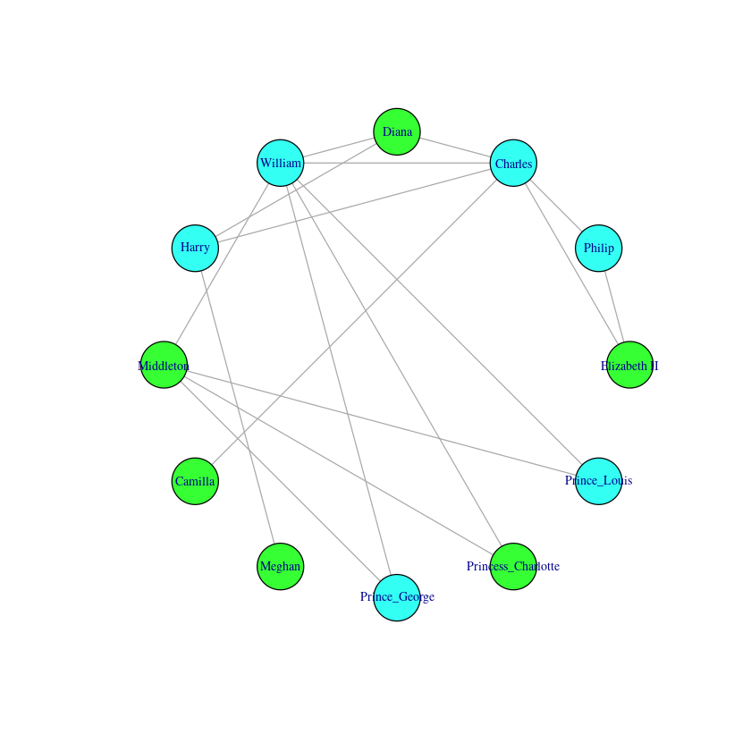

png

```r
# circle 형태
l <- layout_in_circle(royal_g)
plot(royal_g, edge.width = E(royal_g)$weight, vertex.size = 20, layout = l)
```

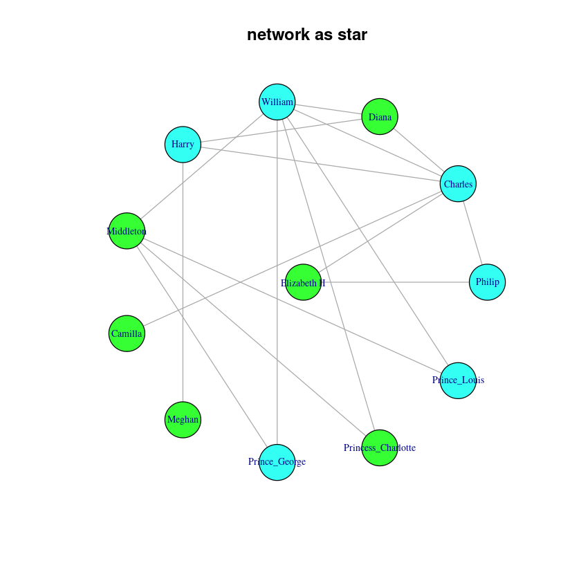

png

```r
# star 형태
l <- layout_as_star(royal_g)
plot(royal_g, edge.width = E(royal_g)$weight, vertex.size = 20, layout = l, main = "network as star")
```

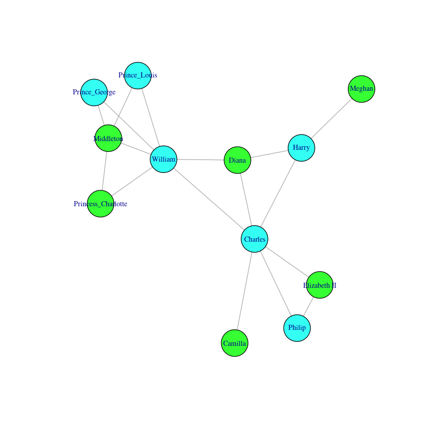

png

```r
# force-directed 형태
l <- layout_with_fr(royal_g)
plot(royal_g, edge.width = E(royal_g)$weight, vertex.size = 20, layout = l)
```

```r
# 여러 형태들로 표현
layouts = c("layout_with_fr", "layout_with_kk", "layout_with_dh", "layout_with_gem", "layout_as_star", "layout_as_tree", "layout_in_circle", "layout_on_grid")
par(mfrow = c(2, 4), mar = c(1, 1, 1, 1))

for (layout in layouts) {
    l <- do.call(layout, list(royal_g))
    plot(royal_g, edge.width = E(royal_g)$weight, vertex.size = 30, layout = l, main=layout)
}

dev.off()
```

**null device:** 1

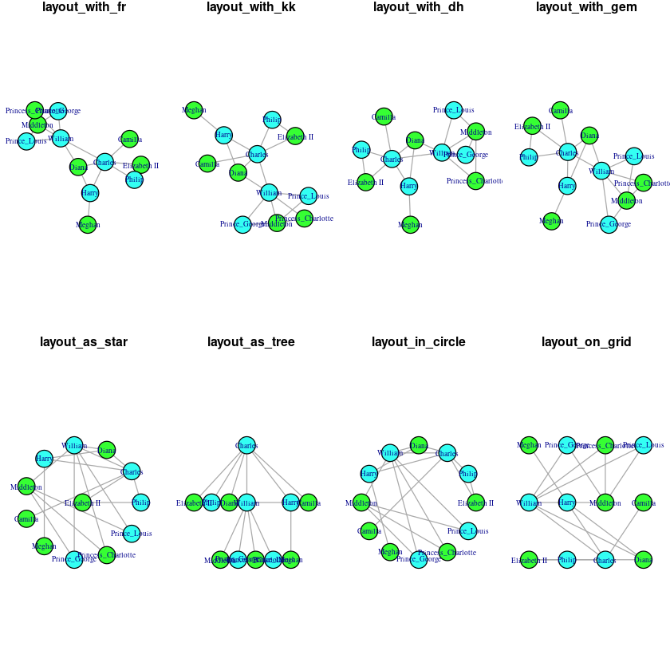

png

##### 노드의 특성 측정

- node centrality(중심성) 측정
  - degree: the number of edges connected to a given node (e.g. the number of friends an individual has in a social network)
  - strength: the sum of the weights of edges connected to the node
  - betweenness: the number of geodesic paths (shortest paths) that go through a given node

```r
# node degree 측정
print(degree(royal_g))
```

```
      Elizabeth II             Philip            Charles              Diana
                 2                  2                  6                  3
           William              Harry          Middleton            Camilla
                 6                  3                  4                  1
            Meghan      Prince_George Princess_Charlotte       Prince_Louis
                 1                  2                  2                  2
```

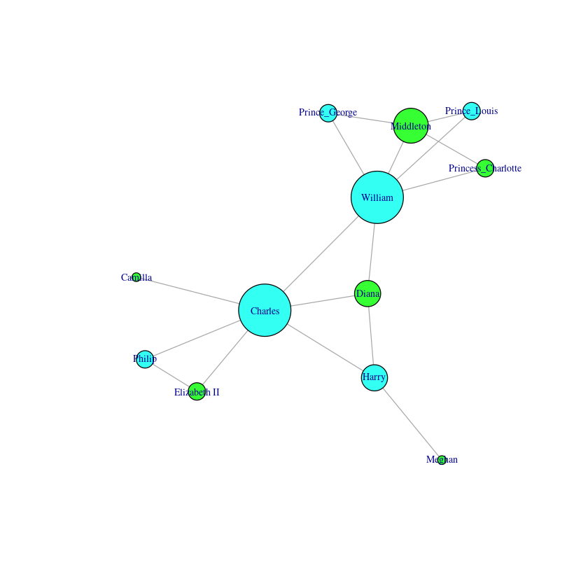

png

```r
de <- degree(royal_g)
plot(royal_g, edge.width = E(royal_g)$weight, vertex.size = de*5)
```

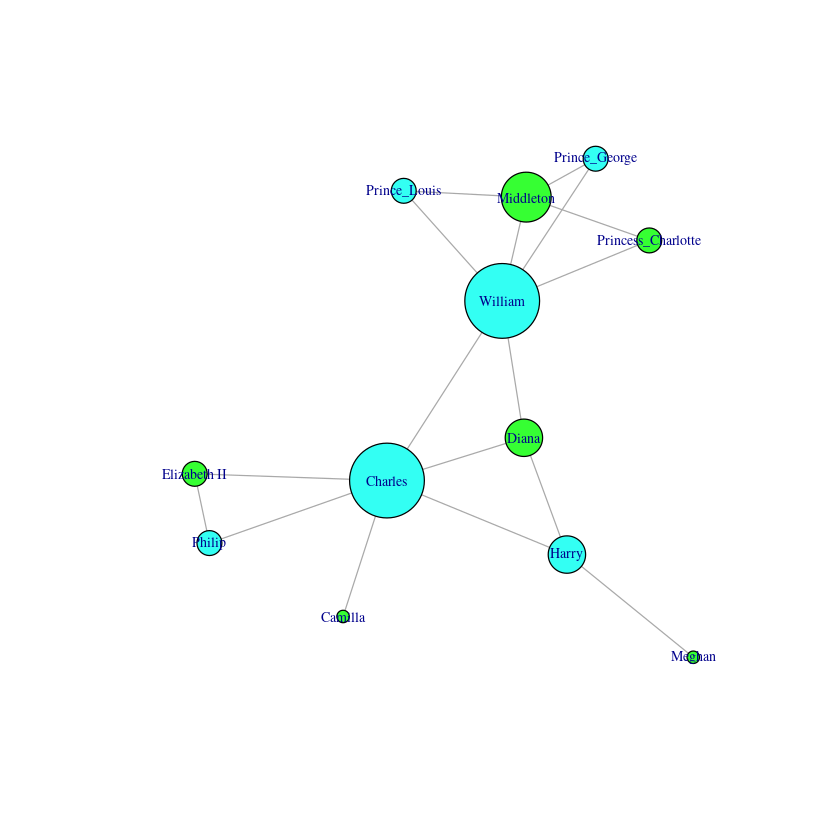

png

```r
# node strength 측정
st <- graph.strength(royal_g)
plot(royal_g, edge.width = E(royal_g)$weight, vertex.size = st*5)
```

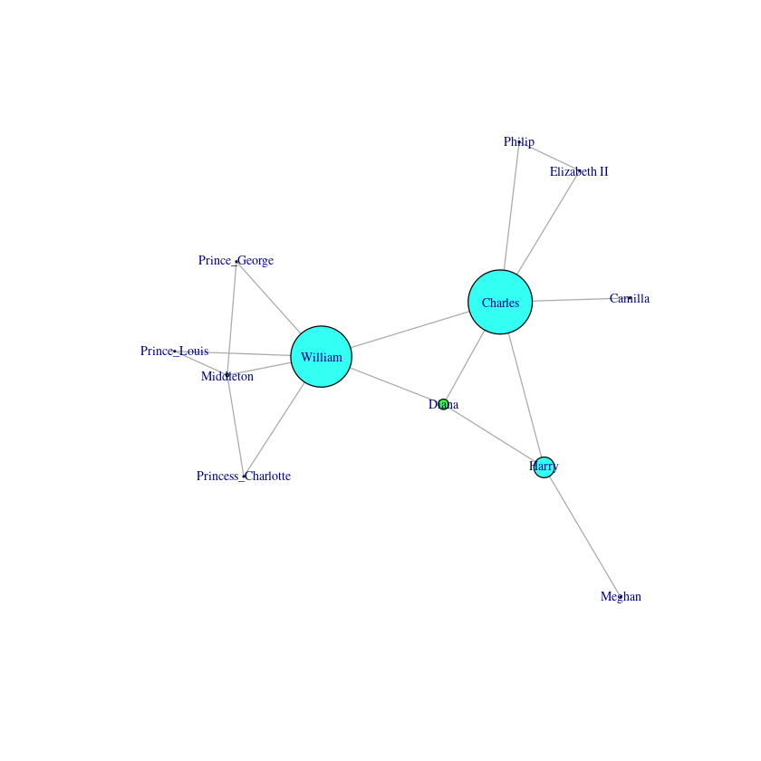

png

```r
be <- betweenness(royal_g, normalized = TRUE)
plot(royal_g, edge.width = E(royal_g)$weight, vertex.size = be*50)
```

```r
print(be)
```

```
      Elizabeth II             Philip            Charles              Diana
        0.00000000         0.00000000         0.56363636         0.09090909
           William              Harry          Middleton            Camilla
        0.53636364         0.18181818         0.02727273         0.00000000
            Meghan      Prince_George Princess_Charlotte       Prince_Louis
        0.00000000         0.00000000         0.00000000         0.00000000
```

##### 그래프의 특성 측정

- 네트워크의 크기
- 네트워크 밀집도(density)

```r
# 그래프의 크기
vn <- vcount(royal_g)
en <- ecount(royal_g)
print(paste("The number of vertices is", vn))
print(paste("The number of edges is", en))
```

```
[1] "The number of vertices is 12"
[1] "The number of edges is 17"
```

```r
# 그래프 밀집도
# 밀집도 = [존재하는 엣지의 수] / [가능한 모든 엣지의 수(최대 엣지 수)]
max_en_directed <- en * (en - 1)    # directed graph인 경우
density_directed <- en / max_en_directed
print(density_directed)

max_en_undirected <- en * (en - 1) / 2    # undirected graph인 경우
density_undirected <- en / max_en_undirected
print(density_undirected)
```

```
[1] 0.0625
[1] 0.125
```

##### 실제 데이터로 네트워크 만들어 보기: citation 데이터 네트워크

- 미국 연방대법원 판결간의 인용 관계: 한 판결이 다른 판결을 이용하고 있는가.
- 논문들간의 인용 관계에도 적용 가능

```r
court_citations <- read.csv("./analysis/network/supreme_court/ac.csv")
print(head(court_citations))
print(nrow(court_citations))
```

```
       to   from
1    4US6 3US320
2    4US6   4US1
3  6US280 1US393
4  6US280  1US53
5  6US280 3US133
6 14US179 5US321
[1] 216738
```

```r
g <- graph_from_data_frame(court_citations, directed = FALSE)
g
```

```
IGRAPH 618ba53 UN-- 25417 216738 --
+ attr: name (v/c)
+ edges from 618ba53 (vertex names):
 [1] 4US6   --3US320  4US6   --4US1    6US280 --1US393  6US280 --1US53
 [5] 6US280 --3US133  14US179--5US321  14US179--9US262  15US45 --3US384
 [9] 15US45 --4US436  15US45 --4US441  15US45 --8US421  15US227--13US388
[13] 15US227--2US36   15US290--7US220  15US290--9US262  15US369--11US504
[17] 15US369--11US577 15US369--5US137  15US369--9US115  15US396--1US371
[21] 15US396--4US450  15US396--6US358  15US396--7US73   16US1  --11US603
[25] 16US1  --8US209  16US1  --8US321  16US101--10US8   16US101--11US69
[29] 16US101--3US415  16US101--8US224  16US234--11US481 16US234--2US302
+ ... omitted several edges
```

```r
# # 다음과 같은 방법도 가능
# court_citations <- as.matrix(read.csv("./analysis/network/supreme_court/ac.csv"))
# g <- graph.edgelist(court_citations, directed = FALSE)
```

```r
# 노드의 수가 25417개로 아주 많음. 엣지의 수는 216738개 -> 그래프로 표현하기에 너무 복잡
# 노드의 수를 줄이기 위해 판결 내용 메타 정보를 이용하여 비슷한 내용을 가진 판결들만 추출
themes <- read.csv("./analysis/network/supreme_court/themes.csv")
print(head(themes))
```

```
     usid issue
1  329US1 80180
2 329US14 10500
3 329US29 80250
4 329US40 20150
5 329US64 80060
6 329US69 80100
```

```r
# themes의 issue 중 20040과 20050은 각각 '“desegregation'과 'desegregation, schools'의 내용에 대한 것임. 이 두 주제에 대한 판결 아이디만 추출
selected_themes <- themes[which(themes$issue %in% c(20040, 20050)),]    # 두 번호에 해당하는 정보만 추출
selected_ids <- selected_themes[, "usid"]   # 여기에 해당하는 판결 번호만 추출
print(length(selected_ids))
```

```
[1] 132
```

```r
# 전체 그래프에서 해당 아이디에 해당하는 노드만으로 구성된 네트워크를 다시 얻음.
g_reduced <- induced.subgraph(g, selected_ids)
g_reduced
```

```
IGRAPH 8189130 UN-- 132 729 --
+ attr: name (v/c)
+ edges from 8189130 (vertex names):
 [1] 332US463--332US633 332US633--334US1   334US1  --334US24  333US147--339US629
 [5] 334US1  --339US629 334US1  --339US637 339US629--339US637 339US629--339US637
 [9] 334US1  --339US816 339US637--339US816 339US282--341US50  332US463--345US559
[13] 339US282--345US559 333US28 --346US100 334US1  --346US249 334US24 --346US249
[17] 339US629--346US249 339US282--347US475 339US629--347US483 339US637--347US483
[21] 334US24 --347US497 347US483--347US497 347US483--347US497 347US483--349US294
[25] 347US497--349US294 345US559--349US375 339US629--350US1   339US637--350US1
[29] 332US463--350US85  347US475--350US85  332US463--350US91  349US375--350US91
+ ... omitted several edges
```

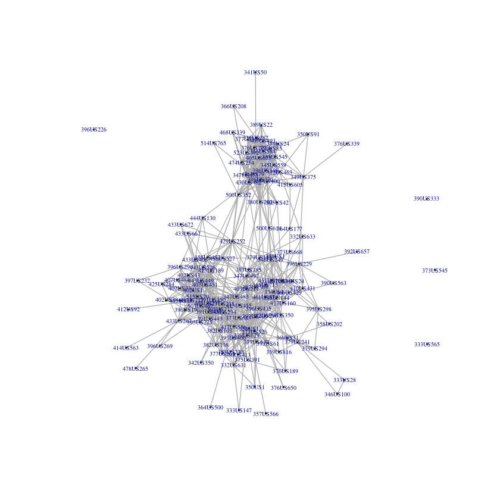

png

```r
l <- layout_with_fr(g_reduced)
plot(g_reduced, layout = l, vertex.size = 0, vertex.label.cex = 0.5)
```

```r
be <- betweenness(g_reduced)    # 각 노드의 betweenness를 구함
print(summary(be))
```

```
    Min.  1st Qu.   Median     Mean  3rd Qu.     Max.
   0.000    2.357   29.263   99.667   95.443 1964.865
```

```r
# 모든 노드에 대해 흰색 색상을 미리 지정. 노드 색상을 흰색을 기본으로 하고 betweenness가 30을 초과하는 노드는 붉은 색으로 따로 지정
colorVals <- rep("white", length(be))
colorVals[which(be > 30)] <- "red"
print(colorVals[1:10])
```

```
 [1] "red"   "white" "white" "white" "red"   "white" "red"   "red"   "red"
[10] "white"
```

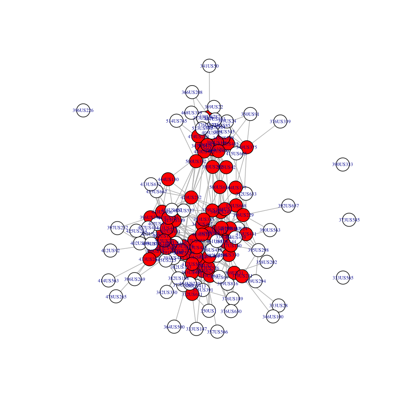

png

```r
# 만들어 놓은 그래프에 노드 색상 적용
V(g_reduced)$color <- colorVals
plot(g_reduced, layout = l, vertex.size = 10, vertex.label.cex = 0.5)
# plot(g_reduced, layout = l, vertex.size = 5, vertex.label = "")
```

```r
# interactive plot 함수 사용
tkplot(g_reduced, layout = l, vertex.size = 10, vertex.label.cex = 0.5)
```

1

```r
# 노드들의 그룹(community)을 확인하고 각 노드를 이 그룹에 할당
# betweenness에 따라 그룹화: betweenness가 가장 높은 엣지를 따라 네트워크를 분할하는 원리
ed_group <- edge.betweenness.community(g_reduced)
print(membership(ed_group)[1:5]) # 각 노드가 어떤 커뮤니티에 속하는지 확인(membership 함수)
cat("----------------\n")
print(length(unique(membership(ed_group)))) # 분할된 그룹의 수
```

```
332US463 332US633  333US28 333US147   334US1
       1        2        3        4        5
----------------
[1] 35
```

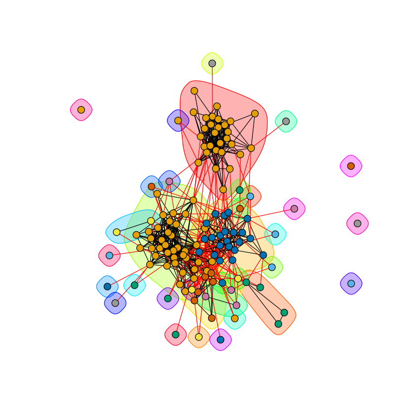

png

```r
# ed_group, 즉 노드의 그룹 정보를 같이 포함해서 그래프 생성.
plot(ed_group, g_reduced, layout = l, vertex.size = 5, vertex.label = "")
```

```r
# Louvain 알고리즘을 이용한 그룹화
lv_group <- cluster_louvain(g_reduced)
print(membership(lv_group)[1:5])
cat("----------------\n")
print(length(unique(membership(lv_group))))
```

```
332US463 332US633  333US28 333US147   334US1
       1        2        2        3        2
----------------
[1] 8
```

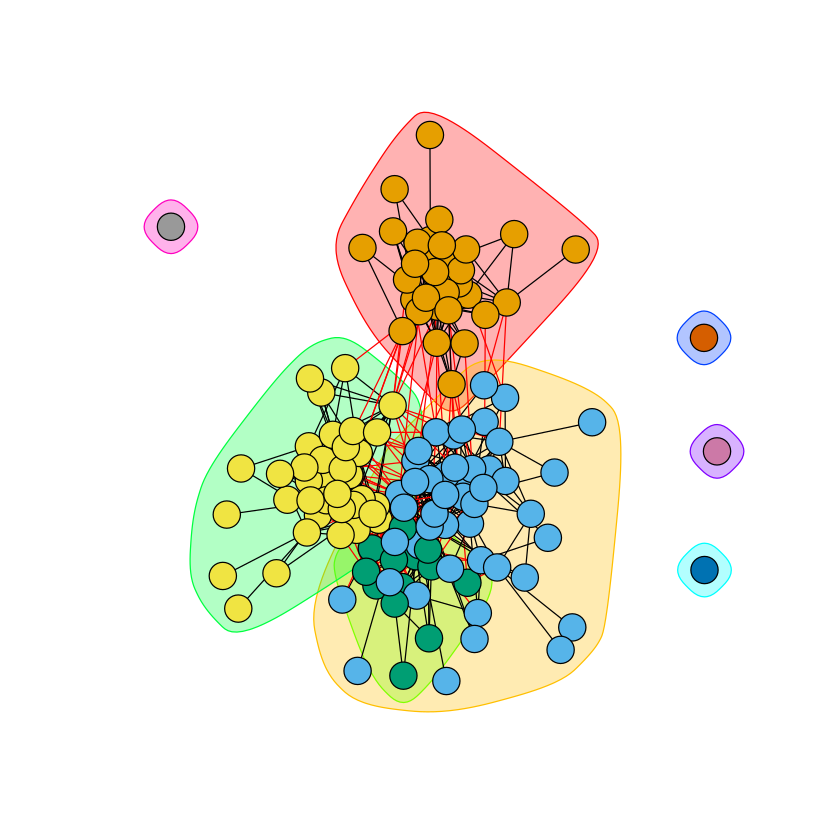

png

```r
plot(lv_group, g_reduced, layout = l, vertex.size = 10, vertex.label = "")
```

##### 문학 텍스트로 네트워크 만들어보기

- V. Woolf의 작품 속에 등장하는 queer 어휘의 관련어 네트워크(동시 출현 네트워크)
  - Woolf의 작품 속에서 queer가 나타나는 문장들만 추출
  - 각 문장들 속에서 queer가 어떤 단어들과 같이 사용되는지, 즉 동시 출현 빈도를 이용
  - 이 때 불용어(stopwords)들을 제거
- Love Actually의 등장 인물간의 네트워크
  - 각 씬에 등장하는 인물들은 서로 관계가 있는 것으로 가정(같은 씬에서 서로 대화를 주고 받으므로)
  - 인물들 이름만 남기고 이 인물들의 각 씬별 동시 출현 관계를 얻어 네트워크로 표현

###### Woolf 작품에 나타난 queer의 관련어 네트워크

- 관련어 정의 예시: 동일 문장 내에서 queer와 같이 나타나는 어휘(동시 출현 단어)
  - Woolf의 작품들을 모두 읽은 후
  - 문장으로 분할하고 (형태소 분석을 실시한 후 구분된 문장을 추출)
  - queer가 들어있는 문장들만 추출
  - 이 문장들을 document-term matrix로 만듦

```r
# 품사 분석을 위한 라이브러리 탑재
library(udpipe)
# 분석 모델 로딩
udmodel_english <- udpipe_load_model('/home/amancio/Desktop/ewha_winter_2023/udpipe_model/english-lines-ud-2.5-191206.udpipe')  # 다운로드 받은 모델의 위치는 root부터 시작하는 전체 경로 기입
```

```r
# woolf 폴더에 있는 파일들 목록
woolf_files <- list.files("./data/woolf", "txt", full.names = TRUE)
woolf_files <- woolf_files[!grepl("_even|_sent", woolf_files)]  # 파일 이름에 '_even'이나 '_sent'가 있는 것 제외

woolf_docs <- lapply(woolf_files, readLines)    # lapply와 readLines 함수로 각 파일을 한 줄씩 읽어옴
woolf_docs <- unlist(woolf_docs)    # 모든 작품을 하나의 파일로 합함 -> 리스트를 벡터로 변환

woolf_annotated <- as.data.frame(udpipe_annotate(udmodel_english, woolf_docs))    # 분석
write.csv(woolf_annotated, "./analysis/tagging/woolf_annotated.csv", row.names = FALSE)   # 분석 결과를 woolf_annotated 파일로 저장
```

```r
woolf_annotated <- read.csv("./analysis/tagging/woolf_annotated.csv")   # 저장한 분석 결과를 읽어옴
```

```r
# 문서, 단락, 문장 id를 하나씩 묶어 고유 id를 만듦.
woolf_annotated$unique_sent_id <- paste(woolf_annotated$doc_id,
                                        woolf_annotated$paragraph_id,
                                        woolf_annotated$sentence_id,
                                        sep = "_")
```

```r
# queer가 포함된 (품사 분석하지 않은) 문장 원문을 추출
# queer가 포함된 문장의 고유 id(unique_sent_id)를 먼저 추출
queer_sents_ids <- woolf_annotated$unique_sent_id[grepl("^queer$", woolf_annotated$token)]
print(queer_sents_ids[1:3])
```

```
[1] "doc48_1_3"   "doc294_1_3"  "doc294_1_23"
```

```r
# 고유 id에 해당하는 문장을 추출 후 중복 제거(unique 함수)
raw_sentences_queer <- woolf_annotated$sentence[woolf_annotated$unique_sent_id %in% queer_sents_ids]
raw_sentences_queer <- unique(raw_sentences_queer)
print(raw_sentences_queer[1:3])
```

```
[1] "A queer card."
[2] "One does come across queer sorts as one travels."
[3] "He's indescribably insignificant, and rather queer in his temper, poor dear."
```

```r
# queer가 포함된 품사 분석된 문장을 추출
# queer가 포함된 문장의 고유 id(unique_sent_id)를 먼저 추출
tagged_sentences_queer <- woolf_annotated[woolf_annotated$unique_sent_id %in% queer_sents_ids,]
```

```r
# 고유 id를 기준으로 분리(분석 문장 분리) (split 함수 사용하여 문장 별로 개별적인 데이터프레임을 만듦)
splitted <- split(tagged_sentences_queer, f = tagged_sentences_queer$unique_sent_id)

tagged_sentences_queer <- c()
for (s in splitted) {
    x <- paste(pos_tag_udpipe(s), collapse = " ")
    tagged_sentences_queer <- c(tagged_sentences_queer, x)
}

# # pos_tag_udpipe 함수로 AntConc 포맷으로 변환
# tagged_sentences_queer <- lapply(splitted, function(x) paste(pos_tag_udpipe(x), collapse = " "))
# tagged_sentences_queer <- unlist(tagged_sentences_queer)
```

```r
print(tagged_sentences_queer[1:2])
```

```
[1] "The_DET_the English_NOUN_english fell_VERB_fall silent_ADJ_silent ;_PUNCT_; the_DET_the natives_NOUN_native who_PRON_who walked_VERB_walk beside_ADP_beside the_DET_the donkeys_NOUN_donkey broke_VERB_break into_ADP_into queer_ADJ_queer wavering_ADJ_waver songs_NOUN_song and_CCONJ_and tossed_VERB…
[2] "As_SCONJ_as the_DET_the rooms_NOUN_room in_ADP_in which_PRON_which people_NOUN_people live_VERB_live are_AUX_be apt_VERB_ap to_PART_to give_VERB_give off_ADV_off something_PRON_something of_ADP_of the_DET_the same_ADJ_same shock_NOUN_shock as_ADP_as their_PRON_they faces_NOUN_face when_SCONJ_wh…
```

```r
# 단어의 원형(lemma)와 품사 정보를 이용하기 위해
# 분석 문장의 품사 포맷을 <단어_품사_원형>에서 <원형_품사>로 수정
tagged_sentences_queer_reformat <- c()
for (sent in tagged_sentences_queer) {
    wrds <- gsub("^(.*?)_(.*?)_(.*)$", "\\3_\\2", unlist(strsplit(sent, " ")))
    wrds <- paste(wrds, collapse = " ")
    tagged_sentences_queer_reformat <- c(tagged_sentences_queer_reformat, wrds)
}
```

```r
print(tagged_sentences_queer_reformat[1:2])
```

```
[1] "the_DET english_NOUN fall_VERB silent_ADJ ;_PUNCT the_DET native_NOUN who_PRON walk_VERB beside_ADP the_DET donkey_NOUN break_VERB into_ADP queer_ADJ waver_ADJ song_NOUN and_CCONJ toss_VERB joke_NOUN from_ADP one_PRON to_ADP the_DET other_ADJ ._PUNCT"
[2] "as_SCONJ the_DET room_NOUN in_ADP which_PRON people_NOUN live_VERB be_AUX ap_VERB to_PART give_VERB off_ADV something_PRON of_ADP the_DET same_ADJ shock_NOUN as_ADP they_PRON face_NOUN when_SCONJ see_VERB for_ADP the_DET first_ADJ time_NOUN ,_PUNCT Rachel_PROPN walk_VERB very_ADV slow_ADV downs…
```

```r
# # 위와 동일한 프로세스를 lapply 함수로 구현
# tagged_sentences_queer_reformat <- lapply(tagged_sentences_queer, function(x) {
#     x <- gsub("^(.*?)_(.*?)_(.*)$", "\\3_\\2", unlist(strsplit(x, " ")))
#     x <- paste(x, collapse = " ")
#     return(x)
# })

# tagged_sentences_queer_reformat <- unlist(tagged_sentences_queer_reformat)
# print(tagged_sentences_queer_reformat[1:2])
```

##### Document-term matrix 만들기

- 2차원 매트릭스: 행 -> 문서/문장, 열 -> 단어
- bag-of-words 표현 포맷

```r
# 필요한 라이브러리 탑재
library(tm)
# (1) 품사 분석이 되지 않은 문장 원문(raw_sentences_queer)을 대상으로 할 때
queer_corpus <- Corpus(VectorSource(raw_sentences_queer))   # 문장 집합을 코퍼스로 변환
queer_corpus <- tm_map(queer_corpus, stripWhitespace)   # 공백이 2개 이상 연속으로 나올 때 하나로 변환
queer_corpus <- tm_map(queer_corpus, tolower)   # 모두 소문자로 변환
queer_corpus <- tm_map(queer_corpus, removeNumbers) # 아라비아 숫자 제외
queer_corpus <- tm_map(queer_corpus, removeWords, stopwords('english')) # 불용어 제거
queer_corpus <- tm_map(queer_corpus, removePunctuation) # 구두점 제거
print(inspect(queer_corpus[1:3]))
# 정제된 코퍼스를 document-term matrix로 변환
# 행은 문장, 열은 단어로 표현
queer_m <- DocumentTermMatrix(queer_corpus)
inspect(queer_m[1:5, 1:5])  # 변환된 매트릭스 내용을 볼 때는 inspect 함수 사용
```

```
<<DocumentTermMatrix (documents: 5, terms: 5)>>
Non-/sparse entries: 9/16
Sparsity           : 64%
Maximal term length: 6
Weighting          : term frequency (tf)
Sample             :
    Terms
Docs across card come one queer
   1      0    1    0   0     1
   2      1    0    1   2     1
   3      0    0    0   0     1
   4      0    0    0   0     1
   5      0    0    0   0     1
```

```r
# 단어 대 단어의 매트릭스로 변환 -> 문장-단어 매트릭스를 단어-문장 매트릭스로 변환 후 self multiplication
queer_m <- t(as.matrix(queer_m)) %*% as.matrix(queer_m) # %*%는 매트릭스를 곱하는 오퍼레이터(operator)
print(queer_m[1:5, 1:5])
```

```
        Terms
Terms    card queer across come one
  card      1     1      0    0   0
  queer     1   135      1    7  26
  across    0     1      1    1   2
  come      0     7      1    6   2
  one       0    26      2    2  36
```

```r
# 매트릭스 queer_m의 차원(행과 열)의 수를 확인
print(dim(queer_m))
```

```
[1] 1190 1190
```

```r
queer_g <- graph_from_adjacency_matrix(queer_m, mode = "undirected", weighted = TRUE, diag = FALSE)
queer_g
```

```
IGRAPH a7e6054 UNW- 1190 22560 --
+ attr: name (v/c), weight (e/n)
+ edges from a7e6054 (vertex names):
 [1] card --queer         queer--across        queer--come
 [4] queer--one           queer--sorts         queer--travels
 [7] queer--dear          queer--indescribably queer--insignificant
[10] queer--poor          queer--rather        queer--temper
[13] queer--absorption    queer--anxious       queer--came
[16] queer--classical     queer--complete      queer--deep
[19] queer--difficult     queer--expression    queer--face
[22] queer--fugue         queer--impersonal    queer--minutes
+ ... omitted several edges
```

```r
# 네트워크의노드 수를 줄이기 위해 노드(즉 단어)의 빈도값을 threshold로 사용
freqs <- slam::col_sums(queer_m)
freqs <- sort(freqs, decreasing = TRUE)
print(freqs[1:10])
```

```
  queer     one thought     way    upon looking    like    last     now  little
   2004     604     533     374     367     350     343     325     324     318
```

```r
# 빈도가 31 이상이고 300 미만인 단어들만 선택
freqs <- freqs[which(freqs > 30 & freqs < 300)]
```

```r
# 빈도 threshold를 충족하는 노드만 남김
queer_g <- induced.subgraph(queer_g, names(freqs))
queer_g
```

```
IGRAPH 3bf71bc UNW- 540 12959 --
+ attr: name (v/c), weight (e/n)
+ edges from 3bf71bc (vertex names):
 [1] poor      --rather     come      --came       came      --expression
 [4] come      --face       came      --face       expression--face
 [7] came      --three      expression--three      face      --three
[10] poor      --eyes       face      --eyes       face      --look
[13] eyes      --look       eyes      --lost       look      --lost
[16] eyes      --second     look      --second     lost      --second
[19] expression--wore       face      --wore       eyes      --wore
[22] look      --wore       lost      --wore       second    --wore
+ ... omitted several edges
```

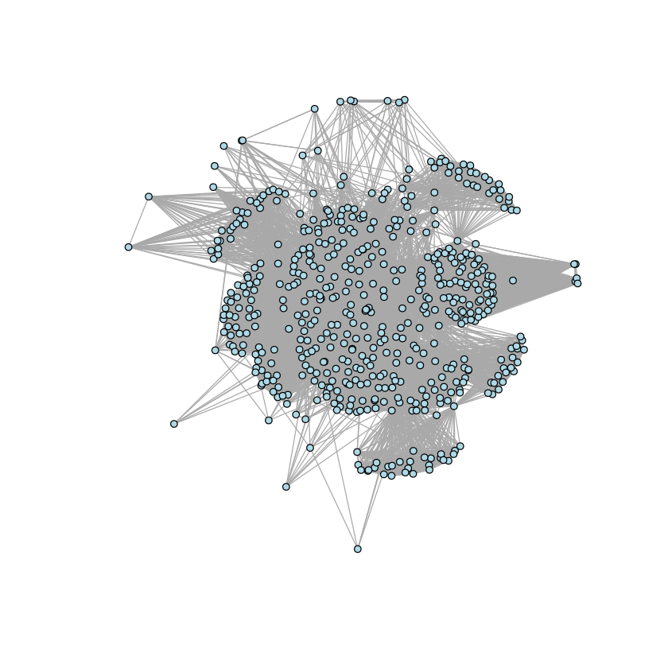

png

```r
l <- layout_with_kk(queer_g)
plot(queer_g, layout = l, vertex.size = 3, vertex.color = "lightblue", vertex.label = "")
```

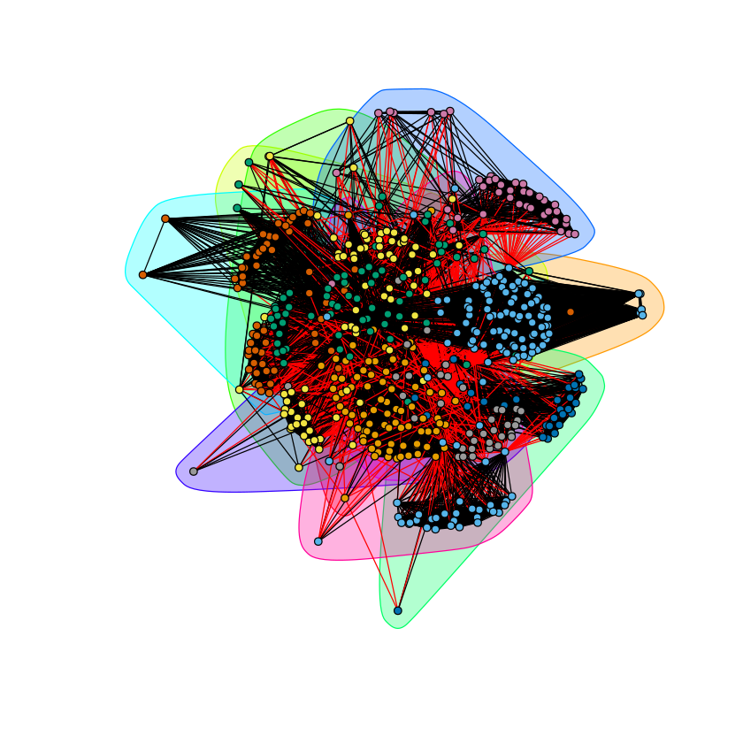

png

```r
lv_group <- cluster_louvain(queer_g)
plot(lv_group, queer_g, layout = l, vertex.size = 3, vertex.label = "")
```

```r
# (2) 품사 분석이 된 문장을 대상으로 할 때
queer_corpus <- Corpus(VectorSource(tagged_sentences_queer_reformat))
queer_corpus <- tm_map(queer_corpus, stripWhitespace)   # 공백만 정제. 나머지 불필요한 요소들(숫자, 불용어 등)은 품사 기호를 이용하여 제거 가능
print(inspect(queer_corpus[1:3]))
# document-term matrix로 변환
queer_m <- DocumentTermMatrix(queer_corpus)
inspect(queer_m[1:5, 1:5])
```

```
<<DocumentTermMatrix (documents: 5, terms: 5)>>
Non-/sparse entries: 12/13
Sparsity           : 52%
Maximal term length: 10
Weighting          : term frequency (tf)
Sample             :
    Terms
Docs ;_punct ._punct and_cconj beside_adp break_verb
   1       1       1         1          1          1
   2       0       1         3          0          0
   3       0       1         1          0          0
   4       0       0         0          0          0
   5       1       1         1          0          0
```

```r
# 단어 - 단어 관계의 매트릭스로 변환
queer_m <- t(as.matrix(queer_m)) %*% as.matrix(queer_m)
print(queer_m[1:5, 1:5])
```

```
            Terms
Terms        ._punct ;_punct and_cconj beside_adp break_verb
  ._punct        140      78       155          2          3
  ;_punct         78     297       372          1          8
  and_cconj      155     372       922          2         16
  beside_adp       2       1         2          2          1
  break_verb       3       8        16          1          2
```

```r
# 매트릭스를 네트워크로 변환
queer_g <- graph_from_adjacency_matrix(queer_m, mode = "undirected", weighted = TRUE, diag = FALSE)
queer_g
```

```
IGRAPH 9f43482 UNW- 1265 52211 --
+ attr: name (v/c), weight (e/n)
+ edges from 9f43482 (vertex names):
 [1] ._punct--;_punct      ._punct--and_cconj    ._punct--beside_adp
 [4] ._punct--break_verb   ._punct--donkey_noun  ._punct--english_noun
 [7] ._punct--fall_verb    ._punct--from_adp     ._punct--into_adp
[10] ._punct--joke_noun    ._punct--native_noun  ._punct--one_pron
[13] ._punct--other_adj    ._punct--queer_adj    ._punct--silent_adj
[16] ._punct--song_noun    ._punct--the_det      ._punct--to_adp
[19] ._punct--toss_verb    ._punct--walk_verb    ._punct--waver_adj
[22] ._punct--who_pron     ._punct--,_punct      ._punct--a_det
+ ... omitted several edges
```

```r
# 품사 기호를 이용하여 네트워크에 남길 노도의 종류를 선택
# selected_nodes_pos <- "noun|adj"
selected_nodes_pos <- "adj"
selected_node_ids <- grep(selected_nodes_pos, V(queer_g)$name)  # 선택한 품사를 가진 노드의 아이디를 얻음
selected_nodes <- V(queer_g)$name[selected_node_ids]    # 해당 아이디에 해당하는 노드 이름을 추출
```

```r
# 품사 기준 외에 빈도 기준도 적용(선택 사항)
freqs <- slam::col_sums(queer_m)
freqs <- sort(freqs, decreasing = TRUE)
freqs <- freqs[which(freqs > 30)]   # 빈도가 31 이상인 것을 선택
```

```r
selected_nodes <- selected_nodes[selected_nodes %in% names(freqs)]  # 품사 기호로 선정한 노드 중에서 빈도 31 이상인 노드를 선정
```

```r
# 네트워크의 크기를 줄임
queer_g <- induced.subgraph(queer_g, selected_nodes)
queer_g
```

```
IGRAPH 5820ef4 UNW- 144 558 --
+ attr: name (v/c), weight (e/n)
+ edges from 5820ef4 (vertex names):
 [1] other_adj       --queer_adj        other_adj       --silent_adj
 [3] queer_adj       --silent_adj       queer_adj       --first_adj
 [5] first_adj       --inexplicable_adj other_adj       --same_adj
 [7] queer_adj       --same_adj         first_adj       --same_adj
 [9] inexplicable_adj--same_adj         first_adj       --satisfactory_adj
[11] inexplicable_adj--satisfactory_adj same_adj        --satisfactory_adj
[13] queer_adj       --able_adj         queer_adj       --desperate_adj
[15] able_adj        --desperate_adj    queer_adj       --half_adj
+ ... omitted several edges
```

```r
# 노드 이름에서 품사 기호 제거
V(queer_g)$name <- gsub("_[a-z]+$", "", V(queer_g)$name)
```

```r
# 만들어진 네트워크를 외부 프로그램(gephi)에서 읽을 수 있는 포맷으로 저장
write_graph(queer_g, "./analysis/network/queer_g_tagged.graphml", format = "graphml")
```

##### Love Actually의 등장 인물간의 네트워크

- 문장 내 동시 출현 단어를 처리할 때와 같은 방식으로 처리
- 등장 인물 이름을 단어로 가정하여 등장 인물 이름만으로 구성된 문장을 생성
- 이 문장들을 위와 동일한 방식으로 처리

```r
# 대본 파일을 읽어온다.
love_actually <- readLines("./analysis/network/love_actually.txt")

# 빈 줄을 삭제한다.
love_actually <- love_actually[which(love_actually != "")]

# 등장 인물 목록을 읽어온다.
love_actually_cast <- read.csv("./analysis/network/love_actually_cast.csv")
love_actually_cast$actor <- gsub(" ", "_", love_actually_cast$actor)    # 성과 이름 사이의 공백을 _ 기호로 변환

print(love_actually[1:10])
cat("-----------------------\n")
print(love_actually_cast[1:3,])
```

```
 [1] "Love Actually Scripts"
 [2] "[ Scene #1 ]"
 [3] "(Man): 'Whenever I get gloomy with the state of the world, "
 [4] "  I think about the arrival's gate at Heathrow airport. "
 [5] "  General opinion started to make out that we live in a world of hatred and greed, "
 [6] "  but I don't see that. Seems to me that love is everywhere. "
 [7] "  Often it's not particularly dignified or newsworthy but it's always there. "
 [8] "  Fathers and sons, mothers and daughters, husbands and wives, boyfriends, girlfriends, old friends. "
 [9] "  When the planes hit the Twin Towers, as far as I know, "
[10] "  none of the phone calls from people on board were messages of hate or revenge, "
-----------------------
  speaker        actor
1      PM   Hugh_Grant
2  Daniel  Liam_Neeson
3   Harry Alan_Rickman
```

```r
# 씬(scene) 구분을 표시하는 표지에 따라 텍스트를 분할한다.
scene_idx <- grep("Scene #\\d+", love_actually) # 각 씬은 '[ Scene #숫자 ]'의 형태로 구분되어 있으므로 이 위치를 찾음.
scene_idx <- c(scene_idx, length(love_actually) + 1)    # 마지막 씬은 마지막 씬의 표지와 텍스트의 마지막 줄 사이이므로 마지막 줄을 idx에 추가

# 각 씬은 '앞선 씬' - '다음 씬' 사이의 텍스트임.
scenes <- list()
for (i in 1:(length(scene_idx)-1)) {
  srt <- scene_idx[i] + 1 # 씬의 시작 위치
  ed <- scene_idx[i+1] - 1  # 씬이 끝나는 위치

  scene <- love_actually[srt:ed]  # 시작 위치와 끝 위치 사이 텍스트를 하나의 씬으로 추출 후 scene에 저장
  scenes[[i]] <- scene  # 추출한 scene을 리스트 scenes에 저장
}

print(paste("The play has", length(scenes), "scenes."))
```

[output not shown]

```r
# 추출한 씬 텍스트를 툴력해 본다.
print(scenes[[2]])
```

```
 [1] "Billy: ♪ I feel it in my fingers ♪ I feel it in my toes ♪ Feel it in my toes, yeah ♪ "
 [2] "  Love is all around me And so the... ♪"
 [3] "Joe: I'm afraid you did it again, Bill."
 [4] "Billy: It's just I know the old version so well, you know."
 [5] "Joe: Well, we all do. That's why we're making the new version."
 [6] "Billy: Right, OK, let's go. ♪ I feel it in my fingers ♪ In my fingers ♪ I feel it in my toes ♪ "
 [7] "  Feel it in my toes, yeah ♪ Love is all ar... ♪"
 [8] "Billy: Oh, fuck, wank, bugger, shitting, arsehead and hole. Start again. ♪ I feel it in my fingers ♪ "
 [9] "  In my fingers ♪ I feel it in my toes ♪ Feel it in my toes, yeah ♪ Christmas is all around me ♪ "
[10] "  All around me ♪ And so the feeling grows ♪ So the feeling grows ♪ It's written in the wind ♪ In the wind ♪ "
[11] "  It's everywhere I go ♪ Everywhere I go  ♪ So if you really love Christmas ♪ Love Christmas ♪ "
[12] "  Come on and let it snow ♪ Come on and let it... ♪ "
[13] "Billy: This is shit, isn't it?"
[14] "Joe: Yup, solid gold shit, Maestro."
```

```r
# 각 씬의 텍스트에서 등장 인물 이름만 추출한다.
scenes_chars <- lapply(scenes, function(x) {
  chars <- gsub("^([a-zA-Z]+):.*$", "\\1", x[grep("^([a-zA-Z]+):", x)]) # 등장인물 이름이 들어있는 행에서 등장인물 이름만 추출

  chars_actor <- c()
  for (char in chars) {
    if (char %in% love_actually_cast$speaker) {
      actor <- love_actually_cast$actor[which(char == love_actually_cast$speaker)]
      chars_actor <- c(chars_actor, paste0(char, "(", actor, ")"))
    }
  }
  return(chars_actor)
})
```

```r
# 각 씬의 등장 인물 이름들을 하나의 문장처럼 이어준다. 이는 tm 라이브러리를 이용하여 document-term matrix를 만들기 위한 것이다.
scenes_chars_ <- lapply(scenes_chars, paste, collapse = " ")
scenes_chars_ <- unlist(scenes_chars_)
scenes_chars_ <- scenes_chars_[scenes_chars_ != ""] # 등장 인물이 없는 씬은 삭제
```

```r
scenes_m <- DocumentTermMatrix(Corpus(VectorSource(scenes_chars_)), control = list(tolower = FALSE))
scenes_m <- t(as.matrix(scenes_m)) %*% as.matrix(scenes_m)
print(scenes_m[1:3, 1:3])
```

```
                    Terms
Terms                Billy(Bill_Nighy) Joe(Gregor_Fisher) Jamie(Colin_Firth)
  Billy(Bill_Nighy)                244                107                  2
  Joe(Gregor_Fisher)               107                 95                  4
  Jamie(Colin_Firth)                 2                  4                446
```

```r
love_g <- graph.adjacency(scenes_m, mode = "undirected", weighted = TRUE, diag = FALSE)
```

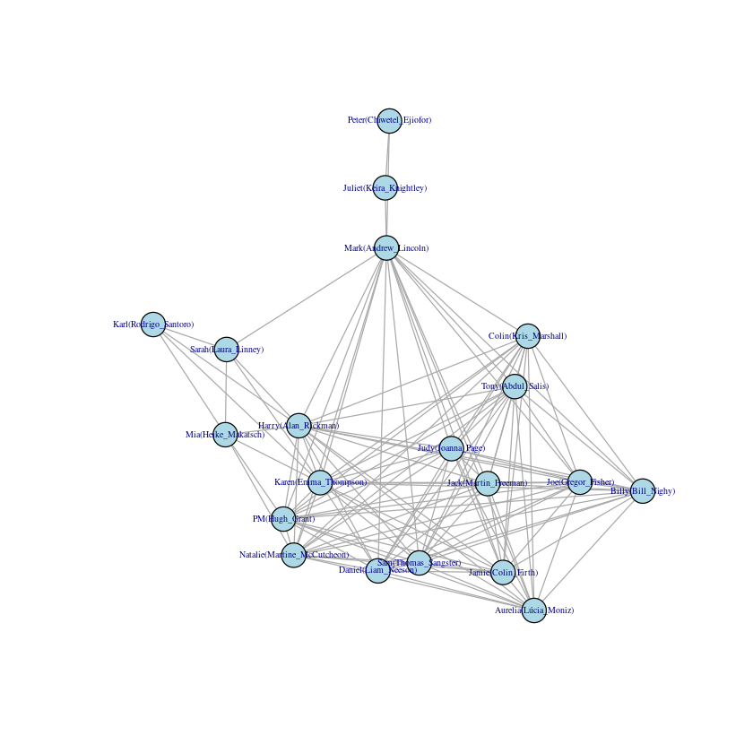

png

```r
l <- layout_with_fr(love_g)
plot(love_g, layout = l, vertex.size = 10, vertex.color = "lightblue", vertex.label.cex = 0.5)
```

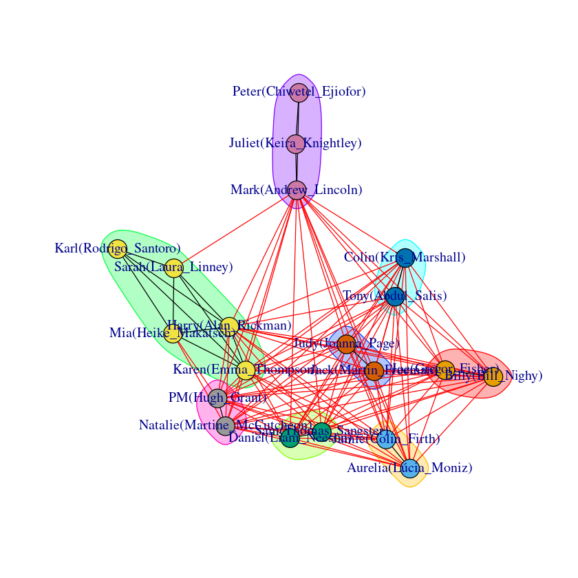

png

```r
lv_group <- cluster_louvain(love_g)
plot(lv_group, love_g, layout = l, vertex.size = 10)
```

```r
write_graph(love_g, "./analysis/network/loveActually_characters.graphml", format = "graphml")
```